# KPB_EXP_1_random

17.05.2023

## Random correlation structures in Experiment 1 of Kiss et al. (2023)

This document focuses on correlation structures between random effects in Kiss et al. (2023).

**Preliminaries:** I am using a model with a random structure that determines random structures for each individual condition, which, in the present case, means for each of the four possible combinations of the two factors: $(0 + factor_{1} * factor_{2} | random)$. Most random slope models make use of a random structure in which random effects are calculated like predictions for fixed factors, i.e. by linear addition: $(1 + factor_{1} * factor_{2} | random)$.

I have, however, added a model of the second type to show that the calculations can also be carried out on the basis of such model. While in the first type of model, we simply compare random factors for each column, e.g. instrumentals/affirmative with comitatives/affirmative, in the second model, the random effect for a slope must be determined by adding the value for the intercept and the value for the respective slope.

#### Libraries

```r
library(lme4)
library(tidyverse)

show(version)
```

```
##                _
## platform       aarch64-apple-darwin20
## arch           aarch64
## os             darwin20
## system         aarch64, darwin20
## status
## major          4
## minor          3.2
## year           2023
## month          10
## day            31
## svn rev        85441
## language       R
## version.string R version 4.3.2 (2023-10-31)
## nickname       Eye Holes
```

#### Read in data set

We’ll use more perspicuous names to address `subjects` and `items`.

#### Empirical distribution of choices

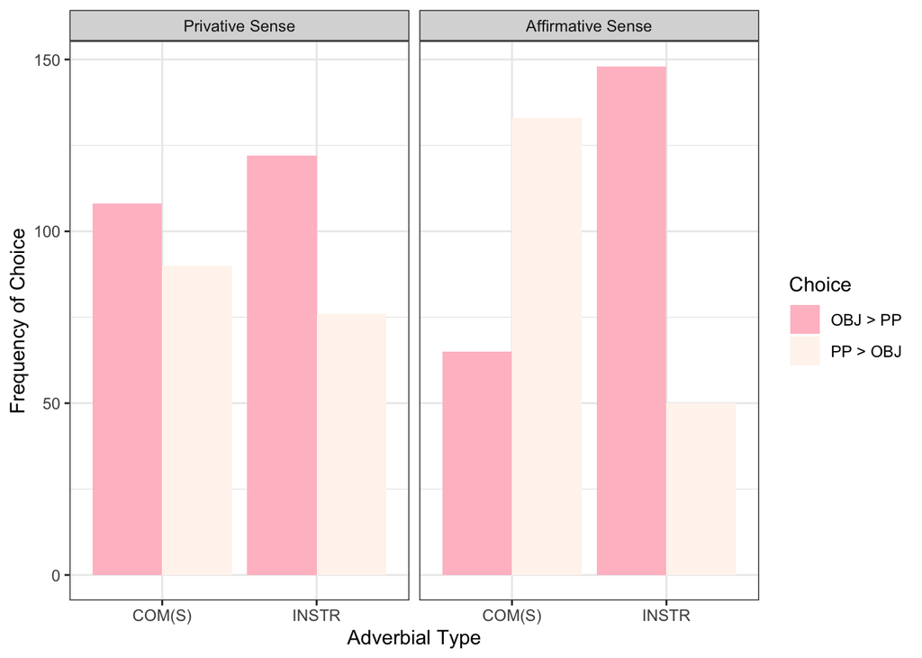

```
##   ADVERBIAL_TYPE       SENSE OBJ>PP PP>OBJ
## 1         COM(S)   privative    108     90
## 2         COM(S) affirmative     65    133
## 3          INSTR   privative    122     76
## 4          INSTR affirmative    148     50
```

#### Random Slope Model with interaction

To provide the analyses used in Kiss et al. (2023), we have to relevel `SENSE` and `ADVERBIAL_TYPE`.

```r
data$SENSE <-
  relevel(data$SENSE, ref = "affirmative")
data$ADVERBIAL_TYPE <-
  relevel(data$ADVERBIAL_TYPE, ref = "INSTR")
```

An initial analysis of both models yield possibly spurious convergence problems. In the first model, we can overcome the convergence problem by restarting, in the second model, a different optimizer is required.

```r
model_0 <-
  glmer(formula = ANSWER ~ ADVERBIAL_TYPE * SENSE +
          (0 + ADVERBIAL_TYPE + SENSE + ADVERBIAL_TYPE:SENSE  | subjects) + (1 | items),
        data = data, family = binomial())
start <-
  getME(model_0, c("theta", "fixef"))

model_0 <-
  update(model_0, start = start,
         control=glmerControl(optCtrl=list(maxfun=2e4)))

options(width = 300)
print(summary(model_0), corr = FALSE)
```

```
## Generalized linear mixed model fit by maximum likelihood (Laplace Approximation) ['glmerMod']
##  Family: binomial  ( logit )
## Formula: ANSWER ~ ADVERBIAL_TYPE * SENSE + (0 + ADVERBIAL_TYPE + SENSE +      ADVERBIAL_TYPE:SENSE | subjects) + (1 | items)
##    Data: data
## Control: glmerControl(optCtrl = list(maxfun = 20000))
##
##      AIC      BIC   logLik deviance df.resid
##    970.0   1040.2   -470.0    940.0      777
##
## Scaled residuals:
##     Min      1Q  Median      3Q     Max
## -2.2556 -0.6492 -0.3626  0.7372  2.5659
##
## Random effects:
##  Groups   Name                                Variance Std.Dev. Corr
##  subjects ADVERBIAL_TYPEINSTR                 0.747688 0.86469
##           ADVERBIAL_TYPECOM(S)                0.512001 0.71554   0.68
##           SENSEprivative                      1.153457 1.07399  -0.12  0.38
##           ADVERBIAL_TYPECOM(S):SENSEprivative 0.235485 0.48527   0.37 -0.16 -0.97
##  items    (Intercept)                         0.001408 0.03753
## Number of obs: 792, groups:  subjects, 33; items, 24
##
## Fixed effects:
##                                     Estimate Std. Error z value Pr(>|z|)
## (Intercept)                          -1.2602     0.2518  -5.005 5.59e-07 ***
## ADVERBIAL_TYPECOM(S)                  2.0591     0.2861   7.198 6.13e-13 ***
## SENSEprivative                        0.6287     0.3275   1.920   0.0549 .
## ADVERBIAL_TYPECOM(S):SENSEprivative  -1.6501     0.3651  -4.520 6.18e-06 ***
## ---
## Signif. codes:  0 '***' 0.001 '**' 0.01 '*' 0.05 '.' 0.1 ' ' 1
```

```r
model_1 <-
  glmer(formula = ANSWER ~ ADVERBIAL_TYPE * SENSE +
          (1 + ADVERBIAL_TYPE + SENSE + ADVERBIAL_TYPE:SENSE  | subjects) + (1 | items),
        data = data, family = binomial(),
        control=glmerControl(optimizer = "nloptwrap",
                             optCtrl = list(algorithm = "NLOPT_LN_NELDERMEAD")))

print(summary(model_1), corr = FALSE)
```

```
## Generalized linear mixed model fit by maximum likelihood (Laplace Approximation) ['glmerMod']
##  Family: binomial  ( logit )
## Formula: ANSWER ~ ADVERBIAL_TYPE * SENSE + (1 + ADVERBIAL_TYPE + SENSE +      ADVERBIAL_TYPE:SENSE | subjects) + (1 | items)
##    Data: data
## Control: glmerControl(optimizer = "nloptwrap", optCtrl = list(algorithm = "NLOPT_LN_NELDERMEAD"))
##
##      AIC      BIC   logLik deviance df.resid
##    970.0   1040.2   -470.0    940.0      777
##
## Scaled residuals:
##     Min      1Q  Median      3Q     Max
## -2.2556 -0.6492 -0.3626  0.7372  2.5660
##
## Random effects:
##  Groups   Name                                Variance Std.Dev. Corr
##  subjects (Intercept)                         0.747825 0.86477
##           ADVERBIAL_TYPECOM(S)                0.414949 0.64417  -0.58
##           SENSEprivative                      1.153642 1.07408  -0.12  0.58
##           ADVERBIAL_TYPECOM(S):SENSEprivative 0.235540 0.48532   0.37 -0.68 -0.97
##  items    (Intercept)                         0.001393 0.03732
## Number of obs: 792, groups:  subjects, 33; items, 24
##
## Fixed effects:
##                                     Estimate Std. Error z value Pr(>|z|)
## (Intercept)                          -1.2603     0.2518  -5.005 5.59e-07 ***
## ADVERBIAL_TYPECOM(S)                  2.0592     0.2861   7.198 6.13e-13 ***
## SENSEprivative                        0.6287     0.3275   1.920   0.0549 .
## ADVERBIAL_TYPECOM(S):SENSEprivative  -1.6501     0.3651  -4.520 6.18e-06 ***
## ---
## Signif. codes:  0 '***' 0.001 '**' 0.01 '*' 0.05 '.' 0.1 ' ' 1
```

### Random correlations

In the following, we plot correlations between the conditions, based on random effects.

```r
ranef_0.df <- data.frame(round(ranef(model_0)$subjects, 2)) %>%
  mutate(participants = rownames(.))

colnames(ranef_0.df)[1:4] <- c("INSTR_aff", "COMS_aff", "INSTR_priv", "COMS_priv")

ranef_0.df <- ranef_0.df %>%
  mutate(b_INSTR_aff = INSTR_aff + model_0@beta[1],
         b_COMS_aff = COMS_aff + model_0@beta[2]) %>%
  as.data.frame()

ranef_0.df
```

```
##     INSTR_aff COMS_aff INSTR_priv COMS_priv participants b_INSTR_aff b_COMS_aff
## 220      0.11    -0.05      -0.91      0.41          220  -1.1502437   2.009143
## 221     -0.20     0.37       1.54     -0.68          221  -1.4602437   2.429143
## 222      0.02     0.02      -0.11      0.05          222  -1.2402437   2.079143
## 223      0.62     1.01       0.97     -0.31          223  -0.6402437   3.069143
## 224     -1.10    -1.17      -1.03      0.27          224  -2.3602437   0.889143
## 225     -0.89    -0.89       0.07     -0.17          225  -2.1502437   1.169143
## 227      0.28     0.82       1.52     -0.59          227  -0.9802437   2.879143
## 228      0.72     0.49      -0.43      0.29          228  -0.5402437   2.549143
## 229      0.47     0.36       0.33     -0.07          229  -0.7902437   2.419143
## 230      0.99     0.41      -0.09      0.17          230  -0.2702437   2.469143
## 231      0.76     0.23      -0.83      0.46          231  -0.5002437   2.289143
## 232      0.75     0.23       0.18      0.02          232  -0.5102437   2.289143
## 234     -0.26    -0.38      -0.59      0.21          234  -1.5202437   1.679143
## 236     -0.61    -0.14       0.67     -0.37          236  -1.8702437   1.919143
```

[output cut: 19 more lines]

```r
ranef_1.df <- data.frame(round(ranef(model_1)$subjects, 2)) %>%
  mutate(participants = rownames(.))

colnames(ranef_1.df)[1:4] <- c("INSTR_aff", "COMS_aff", "INSTR_priv", "COMS_priv")

ranef_1.df <- ranef_1.df %>%
  mutate(COMS_aff_var1 = INSTR_aff + COMS_aff) %>%
  as.data.frame()

ranef_1.df
```

```
##     INSTR_aff COMS_aff INSTR_priv COMS_priv participants COMS_aff_var1
## 220      0.11    -0.16      -0.91      0.41          220         -0.05
## 221     -0.20     0.56       1.54     -0.68          221          0.36
## 222      0.02     0.00      -0.11      0.05          222          0.02
## 223      0.62     0.39       0.97     -0.31          223          1.01
## 224     -1.10    -0.07      -1.03      0.27          224         -1.17
## 225     -0.89     0.00       0.07     -0.17          225         -0.89
## 227      0.28     0.54       1.52     -0.59          227          0.82
## 228      0.72    -0.23      -0.43      0.29          228          0.49
## 229      0.47    -0.11       0.33     -0.07          229          0.36
## 230      0.99    -0.58      -0.09      0.18          230          0.41
## 231      0.76    -0.53      -0.83      0.46          231          0.23
## 232      0.75    -0.53       0.18      0.02          232          0.22
## 234     -0.26    -0.13      -0.59      0.21          234         -0.39
## 236     -0.61     0.47       0.67     -0.37          236         -0.14
```

[output cut: 19 more lines]

The following plot is the one already shown in the paper, with the modification that we only plot the random effects, not the random effects added to the fixed effects.

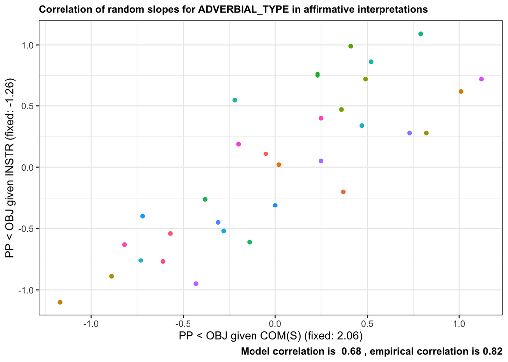

```r
cor_vals <- data.frame(VarCorr(model_0))

ggplot(ranef_0.df, aes(y = INSTR_aff, x = COMS_aff)) +
  geom_point(aes(color = participants), show.legend = FALSE) +
  labs(y = "PP < OBJ given INSTR (fixed: -1.26)",
       x = "PP < OBJ given COM(S) (fixed: 2.06)",
       subtitle = "Correlation of random slopes for ADVERBIAL_TYPE in affirmative interpretations",
       caption = paste("Model correlation is ", round(cor_vals$sdcor[5], 2),
                       ", empirical correlation is",
                       round(cor(ranef_0.df$COMS_aff, ranef_1.df$INSTR_aff), 2))) +
  theme_bw() +
  theme(plot.caption = element_text(face = "bold", size = 10),
        plot.subtitle = element_text(face = "bold", size = 10))
```

The following plot is to show how the two different models yield the same correlation structure (although the models show different correlations).

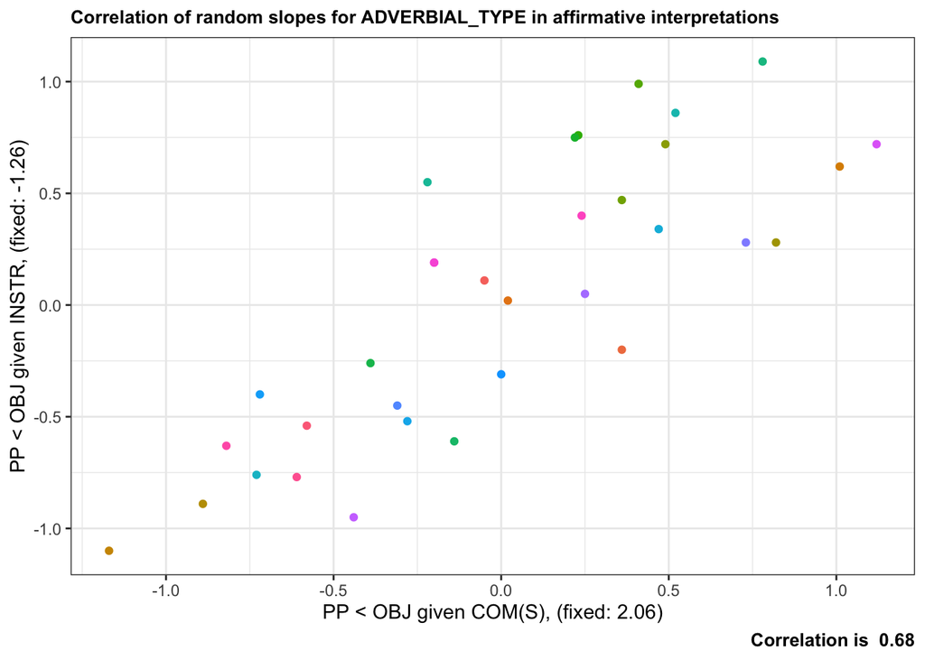

```r
ggplot(ranef_1.df, aes(y = INSTR_aff, x = COMS_aff_var1)) +
  geom_point(aes(color = participants), show.legend = FALSE) +
  labs(y = "PP < OBJ given INSTR, (fixed: -1.26)",
       x = "PP < OBJ given COM(S), (fixed: 2.06)",
       subtitle = "Correlation of random slopes for ADVERBIAL_TYPE in affirmative interpretations",
       caption = paste("Correlation is ", round(cor_vals$sdcor[5], 2))) +
  theme_bw() +
  theme(plot.caption = element_text(face = "bold", size = 10),
        plot.subtitle = element_text(face = "bold", size = 10))
```

```r
ggsave("/Users/tibor/Documents/GitHub/LDS_WS2324/Figures/cor_plot_random_slopes.pdf")
```